# 每週一圖作業

#### 環境設定

以下為老師執行時一定會存在的環境設定

```r
library(dplyr); library(stringr); library(ggplot2); library(plotly); library(lubridate); library(readr); library(tidyr); library(showtext)

font_add("QYuan","cwTeXQYuan-Medium.ttf") # 新增字體
showtext_auto(enable=TRUE) #啟用字體
theme_set(theme_classic())
knitr::opts_chunk$set(out.width='80%', fig.asp=.75, fig.align='center', fig.showtext=T)
```

#### 資料處理

此部份在做：

- 原始Rda資料引入（即引入**dataList**物件）；
- 資料清理成作圖用graphData物件。

請將你最原始的資料連同作業一起上傳到作業上傳網址：  
* 若「原始資料為網頁下載」，且下載指令寫在data cleaning chunk裡的話，可以不用上傳「資料」。  
* 若原始資料有很多個檔案，請先引入成data frame並存在「一個」.Rda檔裡上傳（如`example_data.Rda`檔）。

資料檔引入到進入作圖前的資料處理請寫在下面區塊，分二部份：

- 資料處理
- 作圖用資料物件生成

```r
##討論來自哪個國家的生母，比較可能在較高或較低的年齡層生產(資料來自戶政司在民國107年的統計資料)
graphData <- list()

DownloadFile <- read_csv("http://data.moi.gov.tw/MoiOD/System/DownloadFile.aspx?DATA=B44CB231-00DD-4296-82E8-8A601D33EDF9")
##1.除去不需要的資料
DownloadFile %>%
  select(mother_nation,mother_age,birth_count) -> step1
step1$mother_nation %>%
  str_detect("或地區") -> log1
step1[!(log1),] -> step1 ##相同的`mother_nation`及`mother_age`出現6次是因為原資料有一變數名為`教育程度`，其值有6種結果，之後再處理

##2.改變變數名稱，並且將生母年齡寫成數字
step2 <- step1
names(step2) <- c("生母原屬國籍或地區","生母年齡","嬰兒出生數")

step2$生母年齡%>%
  str_replace("未滿15歲","15") -> step2$生母年齡
step2$生母年齡%>%
  str_replace("15～19歲","19") -> step2$生母年齡
step2$生母年齡%>%
  str_replace("20～24歲","24") -> step2$生母年齡
step2$生母年齡%>%
  str_replace("25～29歲","29") -> step2$生母年齡
step2$生母年齡%>%
  str_replace("30～34歲","34") -> step2$生母年齡
step2$生母年齡%>%
  str_replace("35～39歲","39") -> step2$生母年齡
step2$生母年齡%>%
  str_replace("40～44歲","44") -> step2$生母年齡
step2$生母年齡%>%
  str_replace("45～49歲","49") -> step2$生母年齡
step2$生母年齡%>%
  str_replace("50歲以上","54") -> step2$生母年齡

##3.將各變數類別調整，順便排序levels
step2%>%
  transmute(
    生母原屬國籍或地區=factor(生母原屬國籍或地區,levels=c( "本國","大陸地區", "東南亞地區","港澳地區" ,"其他地區" )),
    生母年齡=as.numeric(生母年齡),
    嬰兒出生數=as.numeric(嬰兒出生數)
  ) -> step3


##4.依生母國籍及年齡層分類，計算出該分類的嬰兒出生總數
step3%>%
  group_by(生母原屬國籍或地區,生母年齡)%>%
   mutate(總嬰兒出生數=sum(嬰兒出生數))%>%
    select(-嬰兒出生數)%>%
      unique() -> step4  ##去除重複的資料(重複原因來自第50行)

##5.計算生母原屬國籍或地區的嬰兒總數，並且新增一變數名為`生母原屬國籍或地區的嬰兒總數`
step4%>%
  group_by(生母原屬國籍或地區)%>%
    summarise(該地嬰兒出生數=sum(總嬰兒出生數)) ->sum_bynation

step4$生母原屬國籍或地區==sum_bynation$生母原屬國籍或地區[1] ->nationlog1
step4$生母原屬國籍或地區==sum_bynation$生母原屬國籍或地區[2] ->nationlog2
step4$生母原屬國籍或地區==sum_bynation$生母原屬國籍或地區[3] ->nationlog3
step4$生母原屬國籍或地區==sum_bynation$生母原屬國籍或地區[4] ->nationlog4
step4$生母原屬國籍或地區==sum_bynation$生母原屬國籍或地區[5] ->nationlog5  ##新增五個logic，用於將生母原屬國籍或地區分類

step5 <- step4
step5$生母原屬國籍或地區的嬰兒總數 <- sum_bynation$該地嬰兒出生數[1]
step5[nationlog2,]$生母原屬國籍或地區的嬰兒總數 <- sum_bynation$該地嬰兒出生數[2]
step5[nationlog3,]$生母原屬國籍或地區的嬰兒總數 <- sum_bynation$該地嬰兒出生數[3]
step5[nationlog4,]$生母原屬國籍或地區的嬰兒總數 <- sum_bynation$該地嬰兒出生數[4]
step5[nationlog5,]$生母原屬國籍或地區的嬰兒總數 <- sum_bynation$該地嬰兒出生數[5]  ##依照類別填入該國嬰兒總數

##6.計算比例，新增名為`嬰兒總數佔該區域嬰兒總數百分比`的變數，並去除不需要的部分
step6 <- step5
step6$嬰兒總數佔該區域嬰兒總數百分比 <- step6$總嬰兒出生數/step6$生母原屬國籍或地區的嬰兒總數
step6%>%
  select(-生母原屬國籍或地區的嬰兒總數,-總嬰兒出生數) ->step6

step6
```

```
## # A tibble: 45 x 3
## # Groups:   生母原屬國籍或地區, 生母年齡 [45]
##    生母原屬國籍或地區 生母年齡 嬰兒總數佔該區域嬰兒總數百分比
##    <fct>                 <dbl>                          <dbl>
##  1 本國                     15                       0.000100
##  2 本國                     19                       0.0138
##  3 本國                     24                       0.0845
##  4 本國                     29                       0.233
##  5 本國                     34                       0.367
##  6 本國                     39                       0.252
##  7 本國                     44                       0.0475
##  8 本國                     49                       0.00212
##  9 本國                     54                       0.000171
## 10 大陸地區                 15                       0
## # ... with 35 more rows
```

```r
graphData$data <- step6
```

#### 繪圖程式

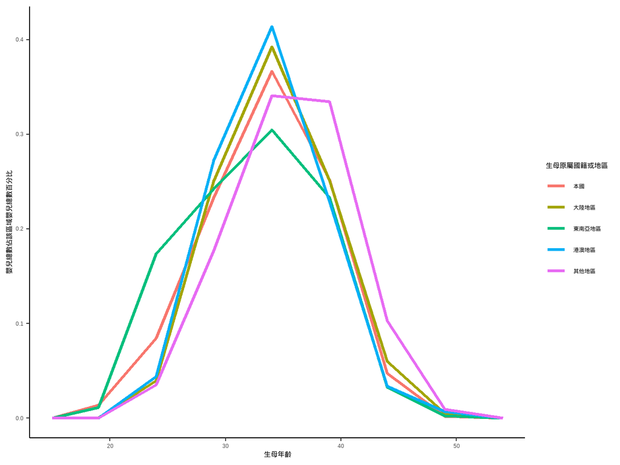

```r
graphData$data%>%
  ggplot()+
  geom_line(size=1.2,
    aes(x=生母年齡,y=嬰兒總數佔該區域嬰兒總數百分比,color=生母原屬國籍或地區)
  )
```

#### 設計說明

說明想傳達的訊息（必要）及設計想法（非必要）。寫在*之後*

此圖表現民國107年時，在台來自各區域的生母，在不同年齡層下生產的嬰兒總數，佔生母原屬區域的嬰兒總數之百分比。圖中我們可以看到大部分的生母都在30至34歲時生產，隨著年齡越小或越大，生產的嬰兒總數就佔越少的百分比。 原屬國籍在東南亞地區的生母在20至24歲生產的比例，遠高於東南亞地區以外的生母在20至24歲時生產的比例，可見比起其他國籍的生母，來自於東南亞地區的生母較有可能在20至24歲生產 原屬國籍在大陸地區的生母，比起台灣、東南亞、港澳地區的生母，更有可能在35歲或以後生產；而原屬國籍在其他地區的生母，在35歲或以後生產的比例特別的高，所以他們是在台灣最有可能成為高齡產婦的族群。